# DataAnalysis

Kristen Hayward

2020-01-24

## PART II

Load packages:

```r
library(dplyr)
```

```r
library(ggplot2)
library(knitr)
```

1. Read measurements.csv into an object in R called MData:

```r
MData<- read.csv("Data/measurements.csv", header = T)
MData
```

```
##     X             Species Limb.Width unitsW Limb.Length unitsL
## 1   1          polar bear 11.3077693     cm 186.7653764     cm
## 2   2         ringed seal 11.6887338     mm 114.2897947     cm
## 3   3        bearded seal 10.8971519     mm 143.2549780     cm
## 4   4    northern lemming 15.7635174     cm  73.8778522     cm
## 5   5              walrus 10.4263086     cm  33.3760443     mm
## 6   6        grizzly bear  0.7236899     mm  55.5073189     cm
## 7   7 american black bear  2.8491506     mm   0.2567381     cm
## 8   8               koala  5.7153224     cm 178.6742405     cm
## 9   9          arctic fox 13.1395331     mm 192.6962490     cm
## 10 10        homo sapiens 16.9035015     cm  93.1682701     mm
```

2. Include functions from the Data Science Tutorial to do each of the following:
1. Change the column names to shorter, 3-letter abbreviations:

```r
#use rename to change column titles - New name = old name
MData<- rename(MData, Spp = Species, LbW = Limb.Width,
               UnW = unitsW, LbL = Limb.Length,
               UnL = unitsL)
```

2. Add a new data column called Volume that calculates limb volume:

```r
#first I'm going to make sure all the units are the same - use ifelse function to change all those not in cm to cm
MData$LbW<- ifelse(MData$UnW == "cm", 1, 0.1)*MData$LbW
MData$LbL<- ifelse(MData$UnL == "cm", 1, 0.1)*MData$LbL
MData$UnW<- "cm"
MData$UnL<- "cm"

#make a new column with volume - limb is cylinder which has the formula V = pi*r2*h
#I used the limb length as the height & the limb width as the diameter of the cylinder
MData<- mutate(MData, Vol = pi*((LbW/2)^2)*LbL)
```

3. Group the species into 2 or more imaginary groups & add a column denoting these groups. I decided to separate the animals into two groups depending on their habitat (terrestrial or marine):

```r
#add column using the mutate function from dplyr
MData<- mutate(MData, Hab = c("terrestrial","marine",
              "marine","terrestrial",
              "marine","terrestrial",
              "terrestrial","terrestrial",
              "terrestrial","terrestrial"))
#make new dataset with data grouped by my new habitat variable
SppHab<- group_by(MData,Hab)
SppHab
```

```
## # A tibble: 10 x 8
## # Groups:   Hab [2]
##        X Spp                     LbW UnW       LbL UnL          Vol Hab
##    <int> <fct>                 <dbl> <chr>   <dbl> <chr>      <dbl> <chr>
##  1     1 polar bear          11.3    cm    187.    cm    18756.     terrestrial
##  2     2 ringed seal          1.17   cm    114.    cm      123.     marine
##  3     3 bearded seal         1.09   cm    143.    cm      134.     marine
##  4     4 northern lemming    15.8    cm     73.9   cm    14418.     terrestrial
##  5     5 walrus              10.4    cm      3.34  cm      285.     marine
##  6     6 grizzly bear         0.0724 cm     55.5   cm        0.228  terrestrial
##  7     7 american black bear  0.285  cm      0.257 cm        0.0164 terrestrial
##  8     8 koala                5.72   cm    179.    cm     4584.     terrestrial
##  9     9 arctic fox           1.31   cm    193.    cm      261.     terrestrial
## 10    10 homo sapiens        16.9    cm      9.32  cm     2091.     terrestrial
```

4. Summarize the mean and SD length, width, and volume for each of my groups & present in table form:

```r
#use summarize function to generate means & SDs
SumGroup<- summarize(SppHab, mean_L = mean(LbL), SD_L = sd(LbL),
          mean_W = mean(LbW), SD_W = sd(LbW),
          mean_V = mean(Vol), SD_V = sd(Vol))
SumGroup
```

```
## # A tibble: 2 x 7
##   Hab         mean_L  SD_L mean_W  SD_W mean_V   SD_V
##   <chr>        <dbl> <dbl>  <dbl> <dbl>  <dbl>  <dbl>
## 1 marine        87.0  73.9   4.23  5.37   180.   90.7
## 2 terrestrial   99.6  84.8   7.34  7.30  5730. 7695.
```

Here is my lovely table:

| Species Habitat | Mean limb length (cm) | SD of limb length (cm) | Mean limb width (cm) | SD of limb width (cm) | Mean limb volume (cm<sup>3</sup>) | SD of limb volume (cm<sup>3</sup>) |
| --- | --- | --- | --- | --- | --- | --- |
| marine | 86.96 | 73.85 | 4.23 | 5.37 | 180.40 | 90.72 |
| terrestrial | 99.58 | 84.80 | 7.34 | 7.30 | 5730.05 | 7695.12 |

However, can also make table kable function:

```r
#round it
SumGroup$mean_L<- round(SumGroup$mean_L, digits = 2)
SumGroup$mean_W<- round(SumGroup$mean_W, digits = 2)
SumGroup$mean_V<- round(SumGroup$mean_V, digits = 2)
SumGroup$SD_L<- round(SumGroup$SD_L, digits = 2)
SumGroup$SD_W<- round(SumGroup$SD_W, digits = 2)
SumGroup$SD_V<- round(SumGroup$SD_V, digits = 2)

kable(SumGroup, caption = "Table 1. Mean and standard deviations for limb width, length, and volume for terrestrial and marine species (n = 10).")
```

Table 1. Mean and standard deviations for limb width, length, and volume for terrestrial and marine species (n = 10).

| Hab | mean_L | SD_L | mean_W | SD_W | mean_V | SD_V |
| --- | --- | --- | --- | --- | --- | --- |
| marine | 86.96 | 73.85 | 4.23 | 5.37 | 180.40 | 90.72 |
| terrestrial | 99.58 | 84.80 | 7.34 | 7.30 | 5730.05 | 7695.11 |

5. Plot width and length BUT embed the graph in R markdown file rather than creating separate PDF. Here, I just plot limb length against width to visualize a potential correlation:

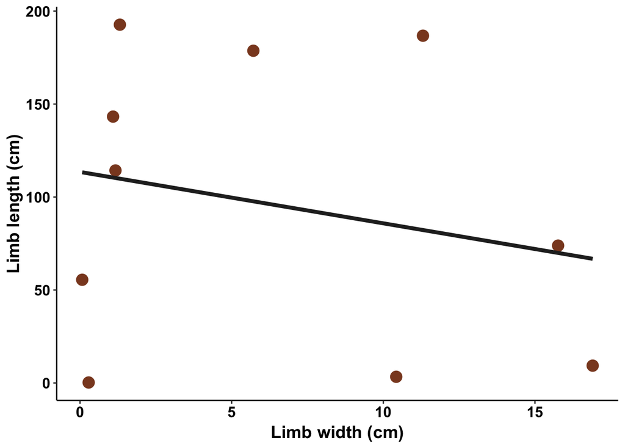

```r
library(ggplot2)
#load the custom theme
cooltoo<- theme(
  legend.position= "none",
  axis.text.x= element_text(size=12, colour="black", face= "bold"),
  axis.text.y= element_text(size=12, colour="black", face= "bold"),
  axis.title.x= element_text(size=14, colour="black", vjust= +0.5, face= "bold"),
  axis.title.y= element_text(size=14, colour="black", vjust=+1, face= "bold"),
  panel.background= element_rect(fill="white", colour=NULL),
  axis.line= element_line(colour="black", size=0.5),
  panel.grid.major = element_blank(),
  panel.grid.minor = element_blank()
  )
#create the plot
ggplot(MData, aes(x = LbW, y = LbL))+
  geom_point(size = 4, colour = "sienna4")+ #alter size & colour of data points
  scale_x_continuous(name = "Limb width (cm)")+ #name the axes
  scale_y_continuous(name = "Limb length (cm)")+
  geom_smooth(method = "lm", se = FALSE, colour = "gray15", lwd = 1.5)+ #add a regression line
  cooltoo #add the custom theme
```

6. Plot width and length, but only for species that have above-average volume:

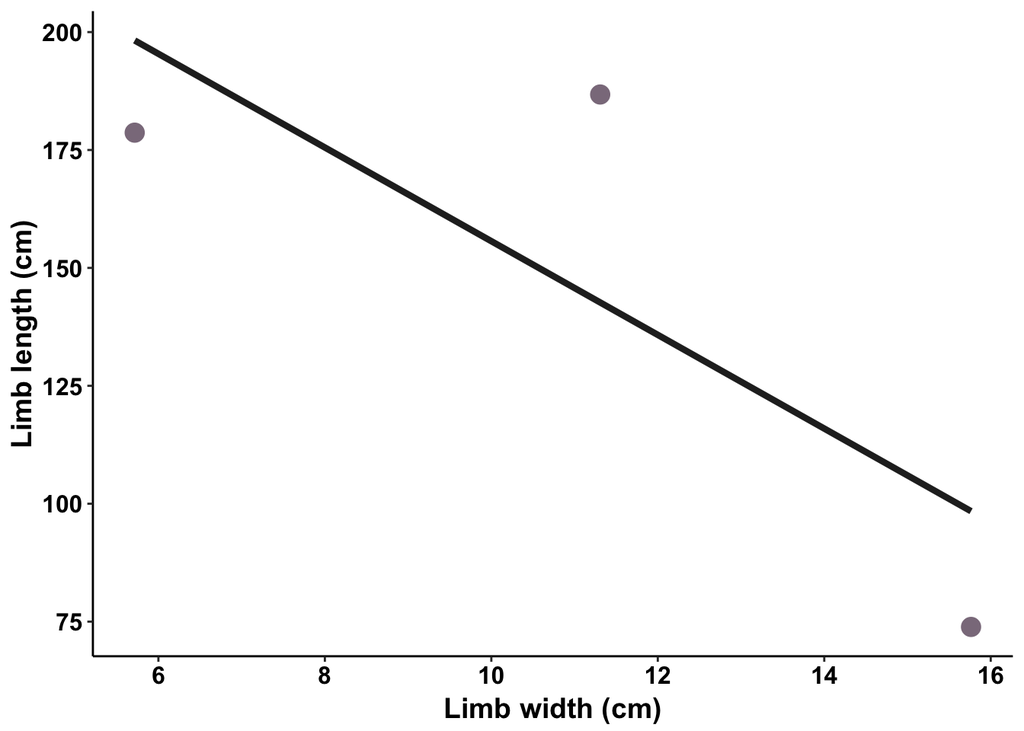

```r
#select only the species with volume above the mean volume - use filter function to subset
AboveAVG<- filter(MData, Vol > mean(MData$Vol))

#now plot limb length vs limb width (like above) but only for these species
ggplot(AboveAVG, aes(x = LbW, y = LbL))+
  geom_point(size = 4, colour = "thistle4")+
  scale_x_continuous(name = "Limb width (cm)")+
  scale_y_continuous(name = "Limb length (cm)")+
  geom_smooth(method = "lm", se = FALSE, colour = "gray15", lwd = 1.5)+
  cooltoo
```

Only three points - not very interesting!

7. Add a table showing only species and volume for only the species with below-average volume:

```r
#select only species with below average volume - use filter function to subset
BelowAVG<- filter(MData, Vol < mean(MData$Vol))

#round the digits
BelowAVG$Vol<- round(BelowAVG$Vol, digits = 3)

#make it into a dataframe for table
BelowAVG<- data.frame("Species" = BelowAVG$Spp,
                      "Volume (cm^3)" = BelowAVG$Vol)

#use kable function to make table or create in markdown text (below):
kable(BelowAVG, caption = "Table 2. Species and their respective limb volumes in cm^3 for species with below average limb volumes from a random sample (n=10).")
```

Table 2. Species and their respective limb volumes in cm^3 for species with below average limb volumes from a random sample (n=10).

| Species | Volume..cm.3. |
| --- | --- |
| ringed seal | 122.640 |
| bearded seal | 133.606 |
| walrus | 284.961 |
| grizzly bear | 0.228 |
| american black bear | 0.016 |
| arctic fox | 261.290 |
| homo sapiens | 2090.794 |